# Discussion 2

Hanying

## Logistics

In our discussion, students are supposed to form random small groups and discuss with each other.

## Summary for R

- Use `read.csv` function to read data from a `.csv` file.
- Use `$` to extract one column from a data frame.
- Use `as.factor()` to transfer a numeric variable to be categorical variable.
- Use `str()` to check the data structure (or try to click the arrow near the variable name in the environment panel).
- Use `View()` to open the data (or try to click the variable name in the environment panel.)
- Use `boxplot()` to create boxplots with the `names =` option to specify the labels of the boxes.
- Use `hist()` to generate histograms with `breaks =` option to specify the breakpoints and `ylim =` option to specify the range of y axis.
- Use `subset()` to extract subset of data. Pay attention to the difference of `==` and `=` (`==` compares the values of both sides and determine whether they are equal. Try `1 == 1` and `1 == 2` and you’ll get `TRUE` and `FALSE`. `=` assigns the value of RHS to the variable LHS. `a = 1` is the same as `a <- 1`. `1 = 1` will create ERROR).
- Use `c()` and `seq()` to create vectors.
- Use R to calculate numeric summaries: `mean()`, `median()`, `sd()`, `quantile()`, and `IQR().`

## Check usage of homework auto-grade and submission

Does anyone have questions about them? In particular,

1. Do you know how to check your answer from previous attempt of AG and improve your solution?
2. A friendly reminder: check the file you submitted to Canvas to ensure that you has included all necessary materials in the file (like the figure).
3. Any issue with homework submission?

## Warm-up

### Plan

Work on the Week 2 Quiz question 6 with your neighbor. Choose the answers you think make sense and explain how you know.

Three minutes to discuss. Then you can explain your answer and the reason.

### Question

Choose the response that best completes the following statement.

Frequency distributions are used when variables are _______, whereas probability distributions are used when variables are _______.

- continuous; discrete
- discrete; continuous
- interval level; ordinal level
- ratio level, nominal level

### Explanation

Frequency distribution reflects how frequently (how often/how many times) a score occurs, and is used for discrete variables, so that we can count the frequency of each score.

Probability distribution reflects the probability or likelihood that a score will occur, and is used for continuous variables.

## Exercise 1

### 10 minutes for group discussion

Every group can share a single laptop. If you prefer, you can choose to work on your own laptops, too.

### Download discussion materials (Exercise 1(a))

- Create a folder for Discussion 2 (Recommended folder names: Disc2, Discussion2). (Right click > new folder > change the folder name)
- Open Canvas, click `Discussion` under `Week 2: Sep 11 - Sep 17`.
- Click all file links to download them into the file you created. (Click the link > Click “Download” in the upper right corner > choose the folder you created for discussion 2.)

### Open file in RStudio (Exercise 1(b))

- Open RStudio
- In the file panel, open the folder for discussion 2
- Click `02 Disc R.Rmd` to open it
- Change Author to your name
- Set working directory to the current folder: Session > Set Working Directory > To files pane location

### Exercise 1(c) Load data

```r
lbw <- read.csv("lbw.csv", header = TRUE)
```

This code means that we used the function `read.csv()` to read the data saved in the file `lbw.csv`. And we created a variable in R named `lbw`, it stores the data.

- Check `lbw` shows in the “environment” panel.
- Click the blue arrow to check the information about it.

### Exercise 1(d)

Try to run `View(lbw)` or click `lbw` in the environment.

## Exercise 2

### 10 minutes for discuss

### 2(a)

- `bwt` is the birth weight (in grams) for each of the 189 babies observed.
- `low` is a variable that is 0 if the birth weight is at least 2500 g and 1 if the birth weight is less than 2500 g.
- `smoke` is a variable that is 0 if mother reported not smoking during pregnancy and 1 if mother reported smoking during pregnancy.

Identify the variable type for each of the three variables based on the description. Check the variable type in R. Does the data type in R agree with the true meaning of these variables?

> The birth weight is numeric. However, `low` and `smooke` are indicators and are categorical variables. They are recognized as integers (int) and thus numeric.

### 2(b)

Run the following code to resave low and smoke as categorical vectors in the lbw data frame. Notice the $ after the data frame name lbw pulls up a list of all of the columns that are defined in lbw. And the as.factor() function changes the variable type to categorical.

```r
lbw$low <- as.factor(lbw$low)
lbw$smoke <- as.factor(lbw$smoke)
```

### 2(c)

Reference the Environment tab or rerun str(lbw) to confirm low and smoke have been updated correctly.

```r
str(lbw)
```

```
## 'data.frame':    189 obs. of  11 variables:
##  $ ID   : int  1 2 3 4 5 6 7 8 9 10 ...
##  $ low  : Factor w/ 2 levels "0","1": 1 1 1 1 1 1 1 1 1 1 ...
##  $ smoke: Factor w/ 2 levels "0","1": 1 1 2 2 2 1 1 1 2 2 ...
##  $ race : int  2 3 1 1 1 3 1 3 1 1 ...
##  $ age  : int  19 33 20 21 18 21 22 17 29 26 ...
##  $ lwt  : int  182 155 105 108 107 124 118 103 123 113 ...
##  $ ptl  : int  0 0 0 0 0 0 0 0 0 0 ...
##  $ ht   : int  0 0 0 0 0 0 0 0 0 0 ...
##  $ ui   : int  1 0 0 1 1 0 0 0 0 0 ...
##  $ ftv  : int  0 3 1 2 0 0 1 1 1 0 ...
##  $ bwt  : int  2523 2551 2557 2594 2600 2622 2637 2637 2663 2665 ...
```

## Exercise 3

Consider comparing the variable for birthweight (bwt) across the groups with smoke = 0 (non smoking) and smoke = 1 (smoking).

### 3a

Create comparative boxplots and histograms of the variable bwt between babies with mothers who had smoking status of 0 = No and 1 = Yes.

### 3a(i)

Save off two data frames, SmokeY and SmokeN, to hold the data for those babies whose mothers smoked and those whose did not

```r
SmokeY <- subset(lbw, smoke == "1")
SmokeN <- subset(lbw, smoke == "0")
```

### 3a(ii)

Then save off the two vectors of bwt for those two dataframes into bwtSmokeY and bwtSmokeN.

```r
bwtSmokeY <- SmokeY$bwt
bwtSmokeN <- SmokeN$bwt
```

### 3a(iii)

Update the following boxplot code to include labels that show which data is which.

Original code:

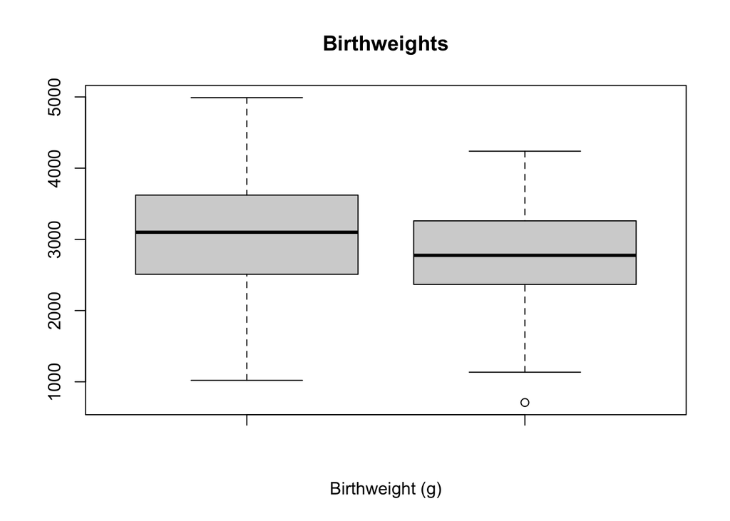

```r
boxplot(bwtSmokeN, bwtSmokeY,
        main = "Birthweights", xlab = "Birthweight (g)")
```

Add name to the figure:

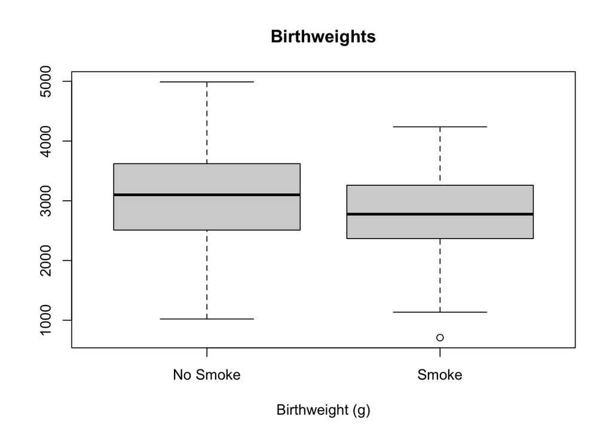

```r
boxplot(bwtSmokeN, bwtSmokeY, names = c("No Smoke", "Smoke"),
        main = "Birthweights", xlab = "Birthweight (g)")
```

### 3a(iv)

Update the following histogram code so that both histgrams have x axis classes from 0 to 5000 with a width of 250.

Original code:

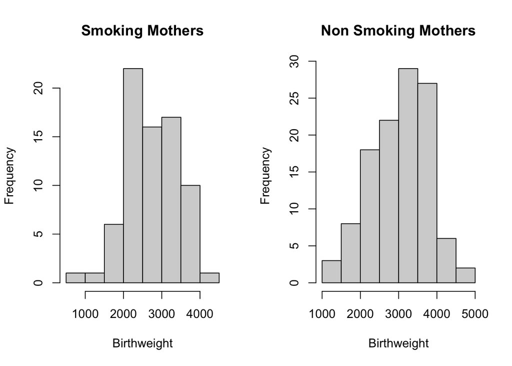

```r
# this makes two rows and 1 column for graphs
par(mfrow = c(1,2))

hist(bwtSmokeY,
     main = "Smoking Mothers", xlab = "Birthweight")

hist(bwtSmokeN,
     main = "Non Smoking Mothers", xlab = "Birthweight")
```

```r
# this makes one row and one column for graphing (restoring to default)
par(mfrow = c(1,1))
```

First, let’s change the bar width. “A histogram has x axis classes from 0 to 5000 with a width of 250” means the breakpoints for the histogram should be `0, 250, 500, ..., 5000`. First recall how to create such a vector:

```r
# start from 0, end at 5000, step length is 250
seq(0, 5000, 250)
```

```
##  [1]    0  250  500  750 1000 1250 1500 1750 2000 2250 2500 2750 3000 3250 3500
## [16] 3750 4000 4250 4500 4750 5000
```

Use this vector as the breakpoints of the histograms:

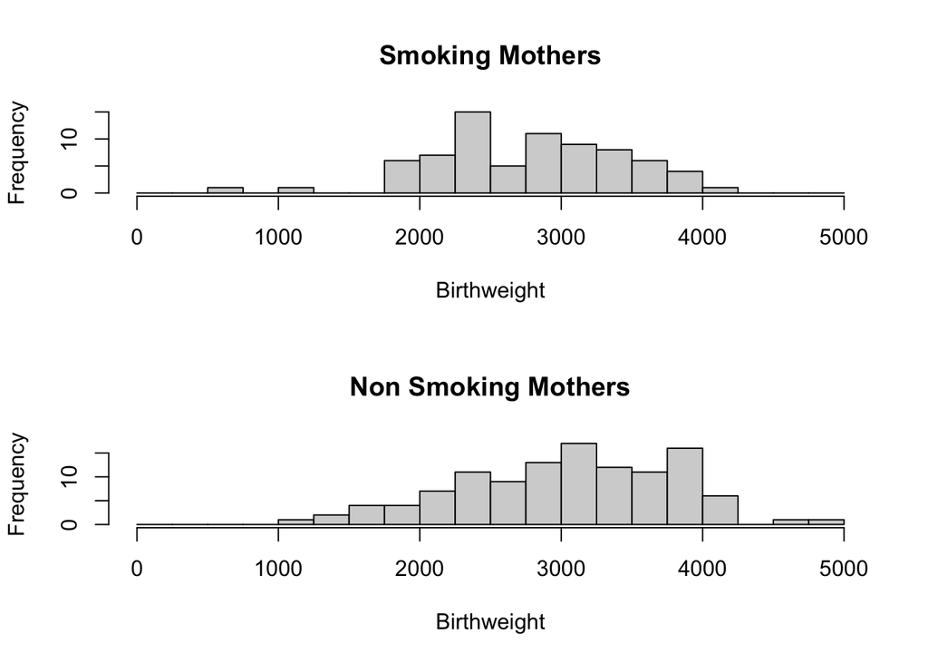

```r
# this makes two rows and 1 column for graphs
par(mfrow = c(2,1))

hist(bwtSmokeY, breaks = seq(0, 5000, 250),
     main = "Smoking Mothers", xlab = "Birthweight")

hist(bwtSmokeN, breaks = seq(0, 5000, 250),
     main = "Non Smoking Mothers", xlab = "Birthweight")
```

```r
# this makes one row and one column for graphing (restoring to default)
par(mfrow = c(1,1))
```

Also, choose a more useful y axis for both graphs.

Observe the figures, we can see the highest bar is around 15.

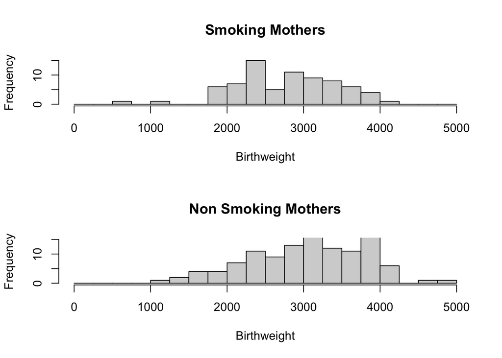

```r
par(mfrow = c(2,1))

hist(bwtSmokeY, breaks = seq(0, 5000, 250), ylim = c(0, 15),
     main = "Smoking Mothers", xlab = "Birthweight")

hist(bwtSmokeN, breaks = seq(0, 5000, 250), ylim = c(0, 15),
     main = "Non Smoking Mothers", xlab = "Birthweight")
```

```r
par(mfrow = c(1,1))
```

We can see some bars in the second histogram is truncated. So, let’s slightly increase the range:

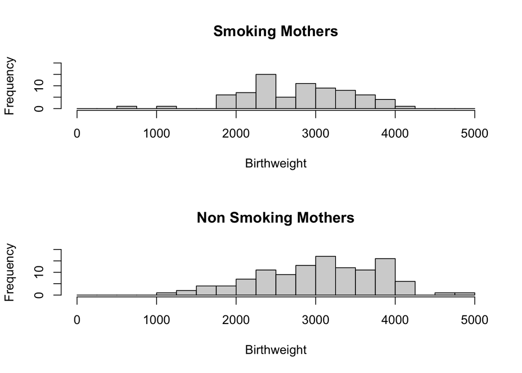

```r
# this makes two rows and 1 column for graphs
par(mfrow = c(2,1))

hist(bwtSmokeY, breaks = seq(0, 5000, 250), ylim = c(0, 20),
     main = "Smoking Mothers", xlab = "Birthweight")

hist(bwtSmokeN, breaks = seq(0, 5000, 250), ylim = c(0, 20),
     main = "Non Smoking Mothers", xlab = "Birthweight")
```

```r
# this makes one row and one column for graphing (restoring to default)
par(mfrow = c(1,1))
```

Why is it important that the x and y axis are consistent across the two histograms?

### 3(b)

Compare the center, variability and shape of the two groups’ data using the graphs and numeric summaries. Write your own code to find the numeric summaries.

Figures we have:

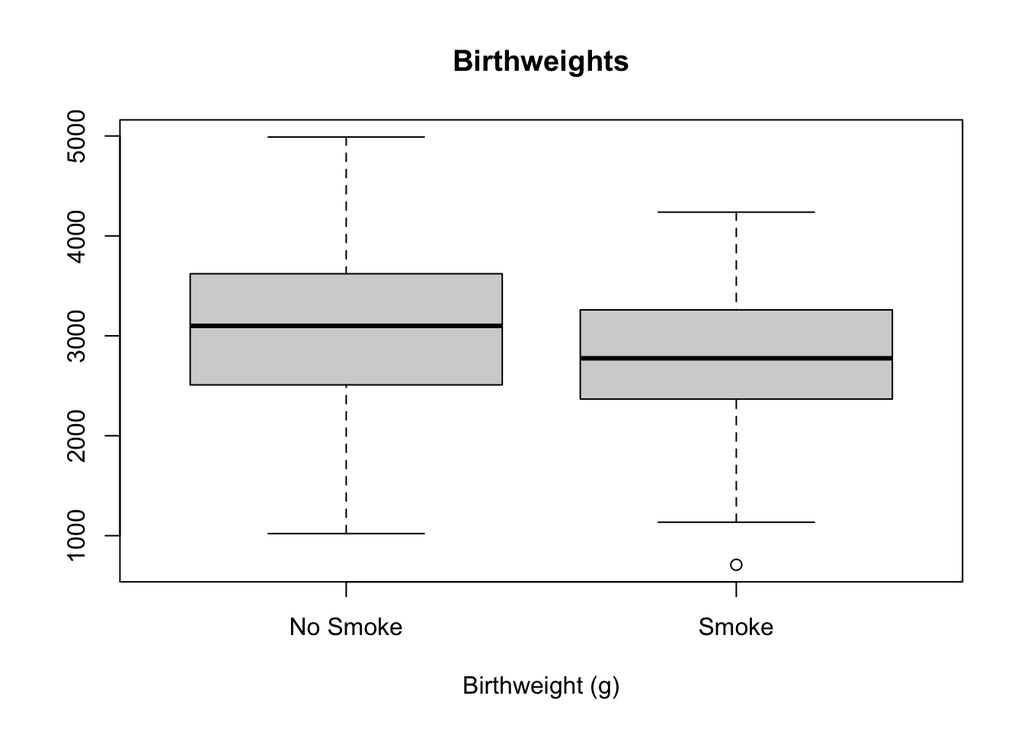

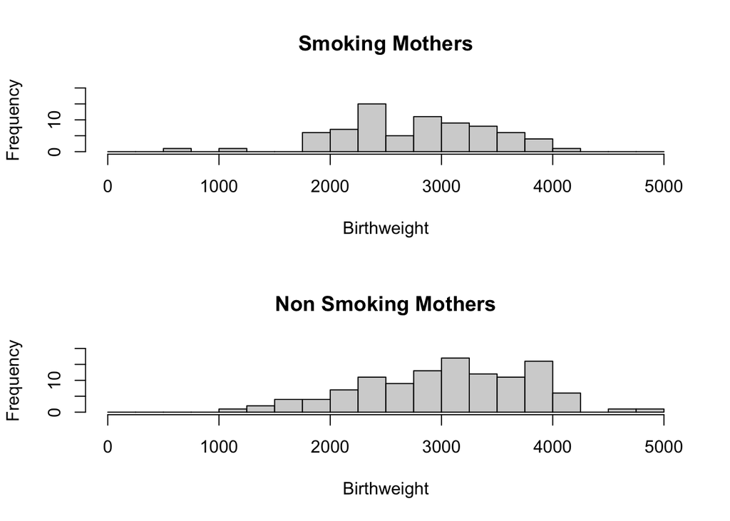

#### Compare the center.

Based on the boxplots: non-smoking group has higher center.

Based on the histograms: non-smoking group has a higher mode (around 3000) than that of the smoking group (around 2400).

Check with the numeric summaries:

```r
# Calculate mean
mean(bwtSmokeN)
```

```
## [1] 3054.957
```

```r
mean(bwtSmokeY)
```

```
## [1] 2772.297
```

```r
# Calculate the median
median(bwtSmokeN)
```

```
## [1] 3100
```

```r
median(bwtSmokeY)
```

```
## [1] 2775.5
```

The non-smoking group is higher than the smoking group in terms of both mean and median, which agrees with our observation from the figures.

#### Compare the variability

Based on the boxplots: the smoke boxplot is shorter.

Based on the histograms: the smoking group is clustered more in the center.

Check with the numeric summaries:

```r
# quantiles
quantile(bwtSmokeN)
```

```
##     0%    25%    50%    75%   100%
## 1021.0 2509.0 3100.0 3621.5 4990.0
```

```r
quantile(bwtSmokeY)
```

```
##      0%     25%     50%     75%    100%
##  709.00 2370.50 2775.50 3245.75 4238.00
```

```r
# standard deciation
sd(bwtSmokeN)
```

```
## [1] 752.409
```

```r
sd(bwtSmokeY)
```

```
## [1] 659.8075
```

IQR for non-smoking: 3621.5 - 2509.0 = 1112.5.

IQR for smoking: 3245.75 - 2370.50 = 875.25.

(Can directly use `IQR` function)

```r
IQR(bwtSmokeN)
```

```
## [1] 1112.5
```

```r
IQR(bwtSmokeY)
```

```
## [1] 875.25
```

We can see that the smoking group has a smaller standard deviation and IQR, which implies that they has smaller variability, which agrees with our observation from the figures.

#### Shape

Both groups’ data looks roughly symmetric in the histograms and boxplots. We see there is 1 outlying value in the smoking group.